# act report

## WeRateDogs - A peek inside for exciting insights.

It is a known fact that dogs and humans share an undeniabe connection. They're man's best friend - and you shouldn't take that title lightly. But these cute friends aren't just cute and cuddly. They're also intelligent and loyal. Little wonder these furry friends rack up ratings like 13/10 (Yes! You read that right!) on the popular dog pet twitter page, WeRateDogs.

WeRateDogs rate people's dogs, usually with a funny comment about the dog attached. Going through the page, I became interested in finding exciting insights about the dogs posted on this page. To find answers to some of the questions I was interested in, I realized I'll need more data (in addition to the `twitter archive` data). This is where data scrapped from Twitter API (`tweet json`) as well as `tweet prediction` data came in handy. With the right exploratory tools, I was able to extract insights, and answer questions like "Which day of the week tend to have the highest tweet engagement?".

Strap in and enjoy, as we dive in and uncover these exciting insights!

### Areas of interest:

1. **Which day of the week tend to have the highest tweet engagement?**
2. **Which dog breed appears most (i.e is most popular) in the WeRateDog twitter page?**
3. **Which dog stages tend to rack up high number of retweets?**

### 1:

#### Which day of the week tend to have the highest tweet engagement?

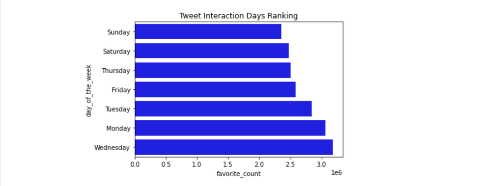

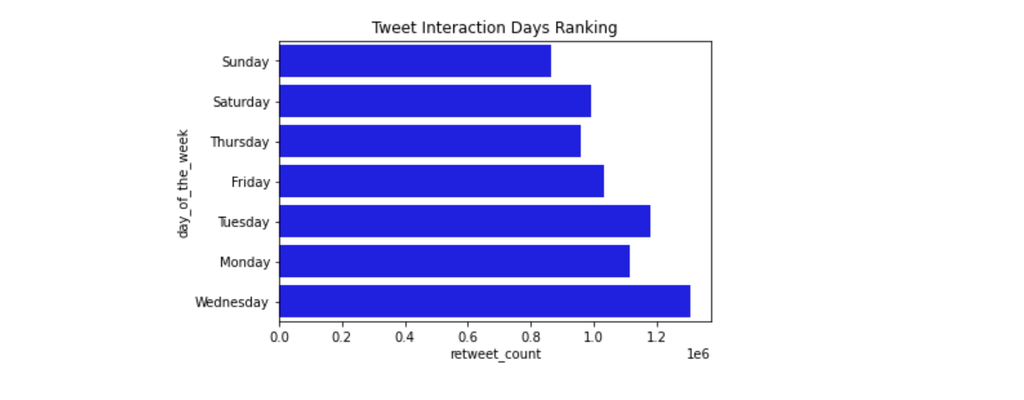

Most tweet engagements/activities are recorded during the mid week. Activities generally tend to start winding down from Thursday, Friday, down to the weekends proper. Across both favorite count and retweet counts, **Wednesday** appears to be the day when most followers are active and are interacting with posts/tweets on the twitter page.

Interesting experiments can be carried out by the twitter page based on this information. One fun way of exploring this could be either by encouraging followers to post during this period, or other find other ways leveraging on this information to drive more engagements on the twitter page.

### 2:

#### Which dog breed appears most (i.e is most popular) in the WeRateDog twitter page?

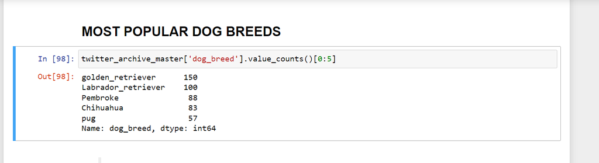

I decided to look through the dog breeds to see which breed makes the most appearance in the dataset.

The **Golden retriever** appear to be the most popular dog breed among followers of the page, since it is the most frequently posted breed by users. It came out top, racking up a hundred and fifty counts against its nearest competitor - the Labrador retriever. The Pembroke, Chihuahua and the Pug, completed the top 5 in that order.

### 3:

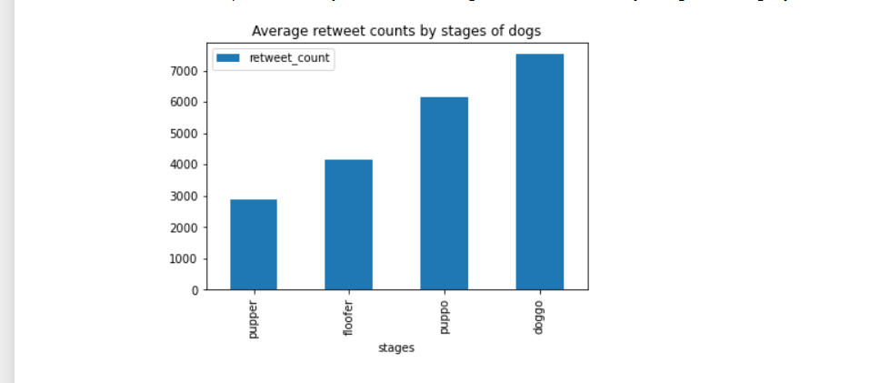

Remember the **doggo**? Cute, fluffy things that have just come of age! Old enough to seeminingly havve their affairs in order, but still with a dose of naivety and inexperience of its smaller cousin - pupper. This makes them all the more adorable. Little wonder then, that dogs that fall within the doggo stage appear to be popular amongst followers, as they have the highest average retweets of the other dog stages. Surprisingly, the puppers get the least retweet counts, with the puppo and floofer sandwiched between them.

### Conclusion

This article was focused on digging up just 3 insights - which is, well, a fraction of what's possible. We explored the data to find out which days of the week are most popular for interacting on the page; which dog breeds make the highest cameos on the dataset; and the dog stages that rack up the highest number of retweets.

It is however important to note that this repoert is merely observational, and more research can be conduced to find out **why** certain trends discovered are so, or ways of using the information deduced from this investigation to improve processes. Other limitations worth noting is the fact that the data on breeds and naming of dogs, as well as categorization of dog stages, were inherently inconsistent. This meant that at instances where few data records were available, under representation is possible.